# Survey Report

The following is an automatically generated report. You can choose the data to be displayed in this report by editing the report_config.json file.

```python
import json
from stats import (
    print_stats,
    print_dont_knows,
    print_n_strong_agrees,
    print_n_agrees,
    print_n_strong_disagrees,
    print_n_disagrees,
    print_n_most_correlated,
    print_n_most_polarizing
)
import matplotlib.pyplot as plt
%matplotlib inline
from utils import get_data
import pandas as pd
pd.options.display.max_colwidth = 100
json_file = open("report_config.json")
json_string = json_file.read()
report_config = json.loads(json_string)

data, q_map = get_data(
    df_file=report_config["data_file"],
    col_names_file=report_config["full_questions_file"],
)
```

### statistics on specific questions

The following questions have been selected for your review:

|  | Q1. I receive training to do my job effectively |
| --- | --- |
| response count (1-5) | 1111 |
| average | 3.80198 |
| median | 4 |
| standard deviation | 1.06477 |
| percent dont know | 0.0560748 |
| most common response | Agree |

|  | Possible Response Key |
| --- | --- |
| 1 | strongly DISAGREE |
| 2 | Disagree |
| 3 | Neutral |
| 4 | Agree |
| 5 | Strongly AGREE |
| 9 | Don't Know |

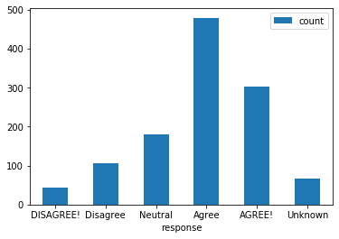

|  | Q55. Senior managers in my department use input from employees to make decisions |
| --- | --- |
| response count (1-5) | 1032 |
| average | 3.07655 |
| median | 3 |
| standard deviation | 1.33844 |
| percent dont know | 0.123195 |
| most common response | Agree |

|  | Possible Response Key |
| --- | --- |
| 1 | strongly DISAGREE |
| 2 | Disagree |
| 3 | Neutral |
| 4 | Agree |
| 5 | Strongly AGREE |
| 9 | Don't Know |

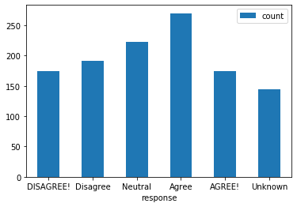

|  | Q60. My co-workers treat me with respect |
| --- | --- |
| response count (1-5) | 1111 |
| average | 4.18812 |
| median | 4 |
| standard deviation | 0.831629 |
| percent dont know | 0.0560748 |
| most common response | Agree |

|  | Possible Response Key |
| --- | --- |
| 1 | strongly DISAGREE |
| 2 | Disagree |
| 3 | Neutral |
| 4 | Agree |
| 5 | Strongly AGREE |
| 9 | Don't Know |

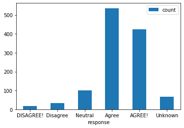

```python
print_stats(
    data=data,
    q_map=q_map,
    questions=report_config["Questions"],
    bar_chart=report_config["Barchart"],
)
```

### Ambigous or Irrelevant questions

These were the top questions that people responded with "I don't know". Note that this could be because the question did not apply to them.

```python
print_dont_knows(data=data,n=report_config["Top N Dont Knows"])
```

|  | Question | Num Don't Knows | Percent Don't Know |
| --- | --- | --- | --- |
| 0 | Q36. As a supervisor, I have been given the training, tools, and resources to lead my work unit | 600 | 50.98% |
| 1 | Q31. As a supervisor, I am supported when addressing staff issues | 591 | 50.21% |
| 2 | Q10c. The following programs/services adequately support my needs: The Safe Haven process | 494 | 41.97% |

### Strongest Agrees

These questions had the highest number of "strong agree" responses:

```python
print_n_strong_agrees(data=data,n=report_config["Top N Strongly Agrees"])
```

|  | Question | Num Strong Agrees | Percent Strong Agree |
| --- | --- | --- | --- |
| 0 | Q15. My immediate supervisor treats me with respect | 566 | 48.09% |
| 1 | Q16. I know what is expected of me | 497 | 42.23% |
| 2 | Q20. My work is appreciated by my immediate supervisor | 460 | 39.08% |

### Strongest Agrees and Agrees

These questions had the highest number of "strong agree" or "agree" responses:

```python
print_n_agrees(data=data,n=report_config["Top N Agrees"])
```

|  | Question | Num Strong Agrees | Percent 'Strong Agree' or Agree |
| --- | --- | --- | --- |
| 0 | Q60. My co-workers treat me with respect | 961 | 81.65% |
| 1 | Q16. I know what is expected of me | 940 | 79.86% |
| 2 | Q15. My immediate supervisor treats me with respect | 914 | 77.66% |

### Strongest Disagrees

These questions had the highest number of "strong disagree" responses:

```python
print_n_strong_disagrees(data=data,n=report_config["Top N Strongly Disagrees"])
```

|  | Question | Num Strong Disagrees | Percent Strong Disagree |
| --- | --- | --- | --- |
| 0 | Q65. Are you proud to work for the City of Tempe? | 967 | 82.16% |
| 1 | Q70. Would like to finish your career with the City of Tempe? | 884 | 75.11% |
| 2 | Q68. Would you recommend the City of Tempe as a place to work to a friend or relative? | 858 | 72.90% |

### Strongest Disagrees and Disagrees

These questions had the highest number of "strong disagree" or "disagree" responses:

```python
print_n_disagrees(data=data,n=report_config["Top N Disagrees"])
```

|  | Question | Num Strong Disagrees | Percent 'Strong Disagree' or Disagree |
| --- | --- | --- | --- |
| 0 | Q71. Have you applied for a new position within the City of Tempe in the past two years? | 1086 | 92.27% |
| 1 | Q65. Are you proud to work for the City of Tempe? | 1014 | 86.15% |
| 2 | Q69. Does the City's working environment and leadership encourage you to go above and beyond the... | 964 | 81.90% |

### Highest correlated responses

In the following cell, I calculate the pearson correlation coefficient between every pair of questions. This measurement could indicate redundancy in the survey or questions were likely to yield a response given a like minded employee. (see: https://en.wikipedia.org/wiki/Pearson_correlation_coefficient)

```python
print_n_most_correlated(data=data,n=report_config["Top N Correlated"])
```

|  | Question 1 | Question 2 | Pearson correlation coefficient |
| --- | --- | --- | --- |
| 0 | Q45. I think the amount I am paid is adequate for the work I do | Q47. Overall, I am reasonably compensated in pay and benefits for the work I do | 0.870394 |
| 1 | Q21. My immediate supervisor gives me clear expectations for work assignments | Q23. I receive constructive feedback on my job performance from my immediate supervisor | 0.866241 |
| 2 | Q21. My immediate supervisor gives me clear expectations for work assignments | Q22. My immediate supervisor makes good use of my time | 0.846077 |

### Most polarizing questions

I developed a measurement of polarization for each question. I define a polarizing question as one that has close to equal number of respondents for "strongly agree" and "strongly disagree" and where most of the responses are either "strongly agree" or "strongly disagree". 0 is the most polarizing and 2 is the least polarizing.

```python
print_n_most_polarizing(data=data,n=report_config["Top N polarizing"])
```

|  | Question | Polarization Score |
| --- | --- | --- |
| 0 | Q71. Have you applied for a new position within the City of Tempe in the past two years? | 0.302174 |
| 1 | Q64. Are you aware of the Council priorities and the City's Strategic Plan (Planning Process)? | 0.338269 |
| 2 | Q69. Does the City's working environment and leadership encourage you to go above and beyond the... | 0.432384 |
| 3 | Q55. Senior managers in my department use input from employees to make decisions | 0.735060 |
| 4 | Q34. I believe exceptional job performance is recognized appropriately by managers/supervisors i... | 0.788143 |